# ¿Quién va con quién?

Laboratori de Biologia Computacional

Expociència - 11 de Maig de 2024

Los animales no viven solos en la naturaleza 🌲. Necesitan de otros para alimentarse o protegerse.

Los parásitos son unos animales muy pequeños 🐛 que necesitan a otro animal 🐗, su hospedador, para poder vivir. El hospedador es un hotel de cinco estrellas para ellos ⭐

Cada especie de parásito puede usar diferentes especies de hospedadores, pero estas infecciones no son al alzar.

El ambiente en el que viven (por ejemplo, acuático 🌊 o terrestre 🏔️) o el tipo de hospedador al que llegan (por ejemplo, ave 🐦 o mamífero 🐗) determina si el parásito llega hasta su hospedador preferido o si se pueden quedar en él.

Veamos como se relacionan entre ellos 6 tipos de parásitos y 6 tipos de hospedadores.

```r
## Red de interacciones
library(bipartite)
comunidad<-matrix(ncol=6,nrow=6,
                  c(1,1,0,0,0,1,
                    1,1,0,0,0,1,
                    1,1,0,0,0,1,
                    1,1,0,0,0,1,
                    0,0,1,1,1,0,
                    0,0,1,1,1,0), byrow=TRUE)
colnames(comunidad)<-c("Acanthocephala", "Annelida", "Cestoda", "Trematoda", "Nematoda", "Arthropoda")
row.names(comunidad)<-c("Ave", "Reptil", "Mamífero", "Rana", "Pez", "Calamar")

## Árboles
library(phytools)
Parasitos <- read.tree(text="((Arthropoda, Nematoda), (((Cestoda, Trematoda),Annelida),Acanthocephala));")
Animales <- read.tree(text="(Calamar,(Pez,(Rana,(Mamífero,(Ave,Reptil)))));")

## Asociaciones
num <- sum(comunidad)
Asociaciones <- matrix(NA, nrow = num, ncol = 2)
cuenta <- 1
for (i in 1:length(rownames(comunidad))) {
  for (j in 1:length(colnames(comunidad))){
    if (comunidad[i,j]==1) {
      a <- cbind(rownames(comunidad)[i], colnames(comunidad)[j])
      Asociaciones[cuenta,] <- a
      cuenta <- cuenta + 1
    }
  }
}
comunidad
```

[output not shown]

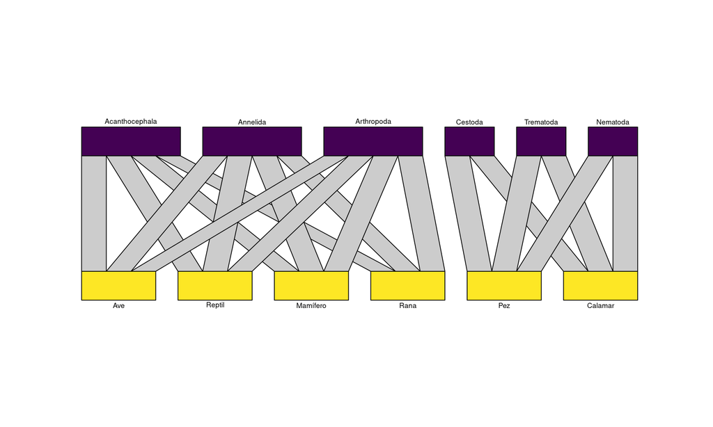

```r
source("plotWeb.R")
plotWeb(comunidad[,c(1,2,6,3,4,5)],
         col.pred = "#440154FF",
         col.prey = "#FDE725FF")
```

```r
## Árbol 1
Sistema<-phytools::cophylo(Animales, Parasitos, assoc = Asociaciones)
```

```
## Rotating nodes to optimize matching...
## Done.
```

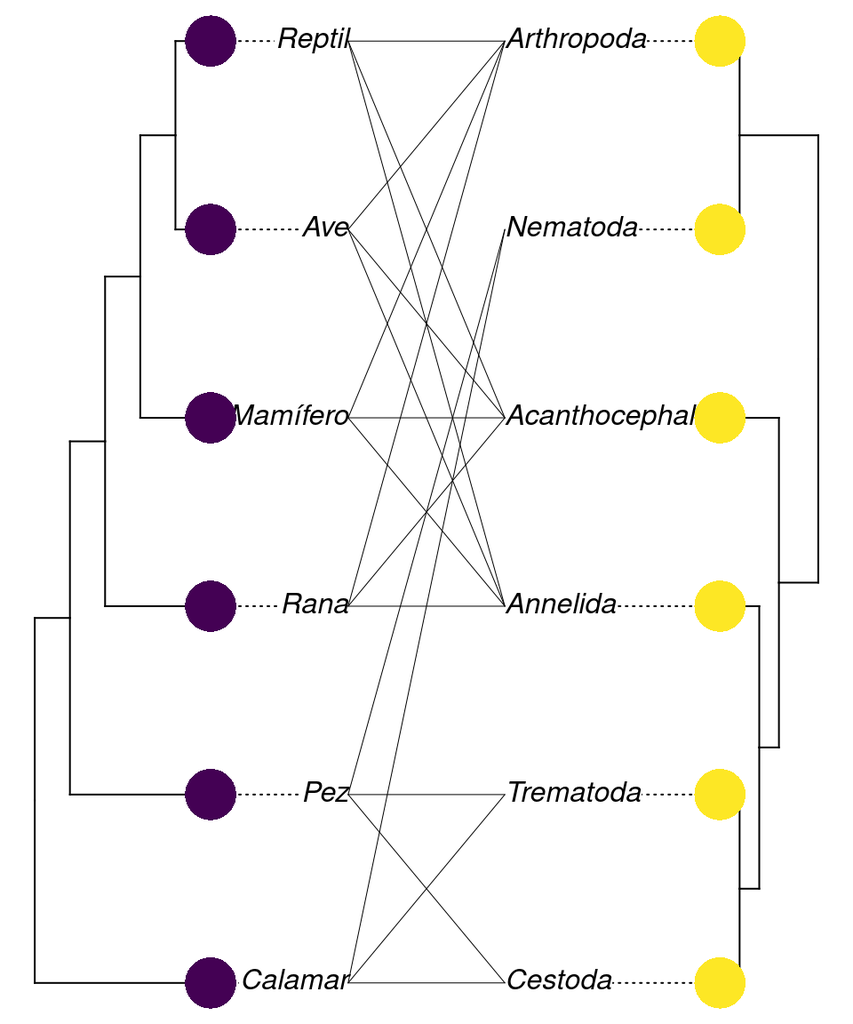

```r
phytools::plot.cophylo(Sistema, cexpt = 1, link.lwd = 0.5, link.lty = 1, fsize = 1, length.line = 0)
phytools::tiplabels.cophylo(pch = 16, col = "#440154FF", cex = 4)
phytools::tiplabels.cophylo(pch = 16, col = "#FDE725FF", cex = 4, which = "right")
```

```r
## Árbol 2
#cophyloplot(Animales, Parasitos, assoc = Asociaciones,space = 32,
#            length.line = 0, gap = -0.5, lwd = 1, lty = 2,
#            show.tip.label = TRUE, font = 0)
```

Vemos que los hospedadores que viven en ambientes terrestres 🏔️ y que son grupos hermano,s comparten los mismos parásitos. Mientras los que viven en el ambiente acuático 🌊 tienen unos parásitos diferentes.

## ¿Y si se juega un poco con ellos?

Pero, ¿qué pasaría si los parásitos pudieran usar otros hospedadores? ¿Siguen los hospedadores terrestres y acuáticos teniendo diferentes parásitos?

### **¡Tirad los dados!**

```r
## Red de interacciones
dados<-matrix(ncol=6,nrow=6,
              c(1,1,0,0,0,1,
                1,1,0,0,0,1,
                1,1,0,0,0,1,
                1,1,0,0,0,1,
                0,0,1,1,1,0,
                0,0,1,1,1,0), byrow=TRUE)
colnames(dados)<-c("Acanthocephala", "Annelida", "Cestoda", "Trematoda", "Nematoda", "Arthropoda")
row.names(dados)<-c("Ave", "Reptil", "Mamífero", "Rana", "Pez", "Calamar")
dados
```

```
##          Acanthocephala Annelida Cestoda Trematoda Nematoda Arthropoda
## Ave                   1        1       0         0        0          1
## Reptil                1        1       0         0        0          1
## Mamífero              1        1       0         0        0          1
## Rana                  1        1       0         0        0          1
## Pez                   0        0       1         1        1          0
## Calamar               0        0       1         1        1          0
```

```r
## Asociaciones
num <- sum(dados)
Asociaciones <- matrix(NA, nrow = num, ncol = 2)
cuenta <- 1
for (i in 1:length(rownames(dados))) {
  for (j in 1:length(colnames(dados))){
    if (dados[i,j]==1) {
      a <- cbind(rownames(dados)[i], colnames(dados)[j])
      Asociaciones[cuenta,] <- a
      cuenta <- cuenta + 1
    }
  }
}
Asociaciones <- unique(Asociaciones)
```

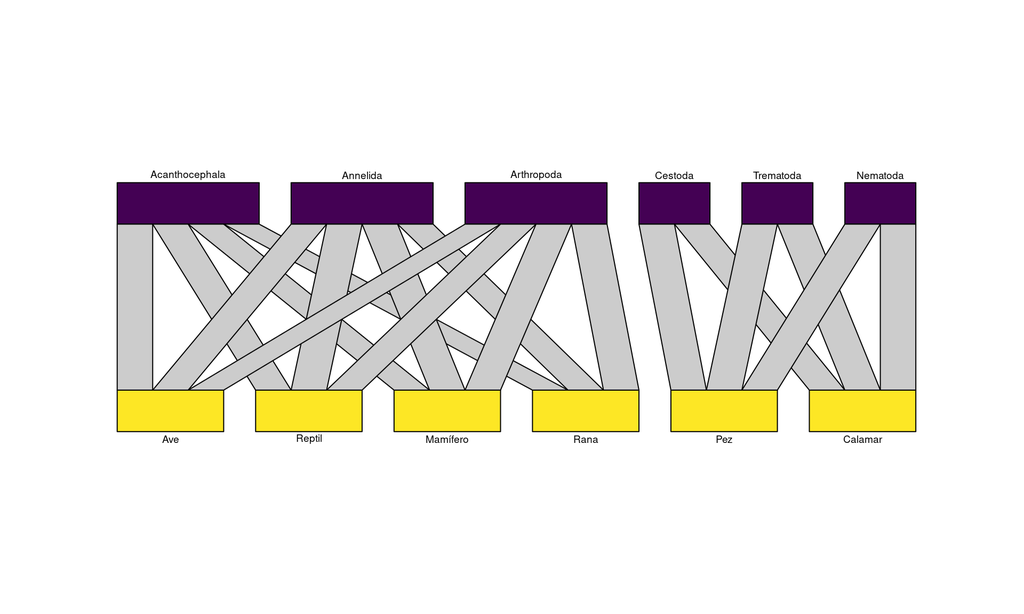

```r
plotWeb(dados[,c(1,2,6,3,4,5)],
         col.pred = "#440154FF",
         col.prey = "#FDE725FF")
```

```r
## Árbol 1
Sistema<-phytools::cophylo(Animales, Parasitos, assoc = Asociaciones)
```

```
## Rotating nodes to optimize matching...
## Done.
```

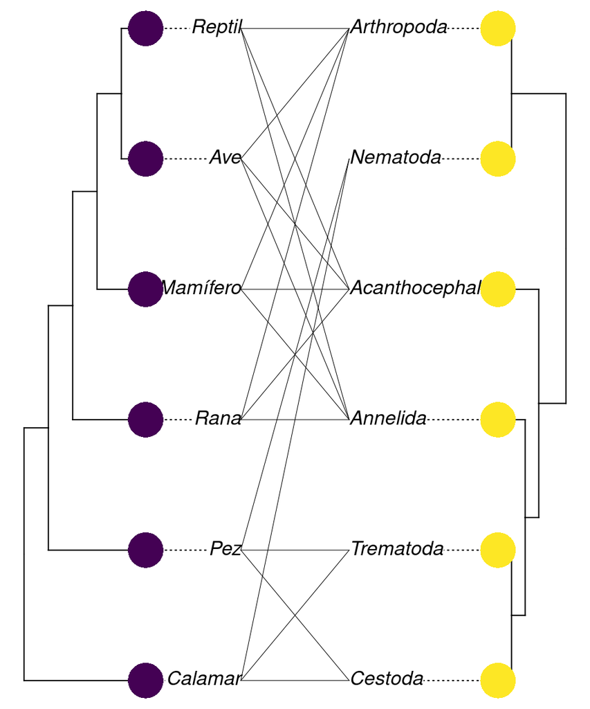

```r
phytools::plot.cophylo(Sistema, cexpt = 1, link.lwd = 0.5, link.lty = 1, fsize = 1, length.line = 0)
phytools::tiplabels.cophylo(pch = 16, col = "#440154FF", cex = 4)
phytools::tiplabels.cophylo(pch = 16, col = "#FDE725FF", cex = 4, which = "right")
```